# Customer Churn Prediction with Logistic Regression

Sebastian Ross

2026-09-12

# 1 Introduction

Customer churn is one of the most consequential problems a retail bank faces. Acquiring a new customer is far more expensive than retaining an existing one, and a customer who leaves takes their deposits, card usage, and cross-sell potential with them. A model that reliably identifies customers at high risk of leaving allows the bank to concentrate retention spending where it is most likely to pay off.

This report develops a binary logistic regression model that predicts churn from a set of customer demographic, financial, and behavioral characteristics. The analysis begins by describing the data and the variables collected, then uses exploratory plots to identify skewness and collinearity among the predictors. Those findings motivate a small number of variable transformations — standardization of continuous predictors and discretization of two non-linear ones — which are applied before the data are partitioned. The data are then split into a training set and a held-out test set, three candidate models (full, reduced, and null) are fit on the training data, and the final model is chosen using cross-validated prediction error and a comparison of ROC curves. The chosen model’s accuracy and AUC are then reported on the withheld test data, which are never used during model fitting or selection.

The outcome of interest is not merely a fitted equation but a defensible answer to three questions: which customer characteristics are most strongly associated with churn, whether the effects of age and product count are better captured by discretization than by a single linear term, and how well the final model discriminates churners from non-churners out of sample.

# 2 Data and Variable Descriptions

The data are a public, observational, cross-sectional sample of 10,000 customers of “ABC Bank,” distributed on Kaggle at https://www.kaggle.com/datasets/gauravtopre/bank-customer-churn-dataset/data. Each row is one customer, and the response `churn` records whether that customer left the bank during some observation period. The records were generated by the bank’s own operational systems rather than by a designed experiment, so the analysis can describe associations between predictors and churn but cannot establish causal effects. The file contains no time dimension, so churn *timing* cannot be modeled — only the binary outcome. The sample is a convenience sample from a single institution and a small number of countries, and results may not generalize to other markets. The dataset contains no missing values, so all 10,000 records are retained for analysis.

## 2.1 Variable names and definitions

The raw file contains twelve variables. `customer_id` is a unique identifier and is dropped before modeling because it carries no predictive information. The remaining eleven variables are listed below.

| Variable | Type | Definition |
| --- | --- | --- |
| `customer_id` | Identifier | Unique customer ID number (dropped) |
| `credit_score` | Numeric | Customer’s credit score |
| `country` | Categorical | Customer’s country of residence (France, Germany, Spain) |
| `gender` | Categorical | Customer’s gender (Female, Male) |
| `age` | Numeric | Customer’s age in years |
| `tenure` | Numeric | Number of years the customer has banked with ABC |
| `balance` | Numeric | Account balance |
| `products_number` | Numeric (count) | Number of bank products the customer holds |
| `credit_card` | Binary | 1 if the customer has a credit card, 0 otherwise |
| `active_member` | Binary | 1 if the customer is an active member, 0 otherwise |
| `estimated_salary` | Numeric | Estimated salary of the customer |
| `churn` | Binary (response) | 1 if the customer left the bank during the period, 0 otherwise |

# 3 Research Question

The objective is to build a logistic regression model that predicts churn from the available customer characteristics and to evaluate how well that model performs on data it has not seen. Three specific questions guide the analysis.

The first concerns **association**: which customer characteristics are most strongly associated with churn after adjusting for the other predictors, and in particular, do the two actionable variables — active membership and number of products held — remain important once demographics and financial variables are controlled for?

The second concerns **functional form**: is it adequate to enter age and product count as single linear terms, or do their relationships with churn require discretization to be captured correctly? The exploratory plots suggest non-monotonic risk patterns for both.

The third concerns **predictive performance**: how well does the selected model discriminate churners from non-churners on held-out data, as measured by cross-validated prediction error and by the test-set ROC curve and AUC?

# 4 Exploratory Analysis

The first step is a visual inspection of the predictor variables. The pairwise scatter-plot matrix below combines density plots on the diagonal, Pearson correlations in the upper triangle, and scatter plots with fitted ellipses in the lower triangle.

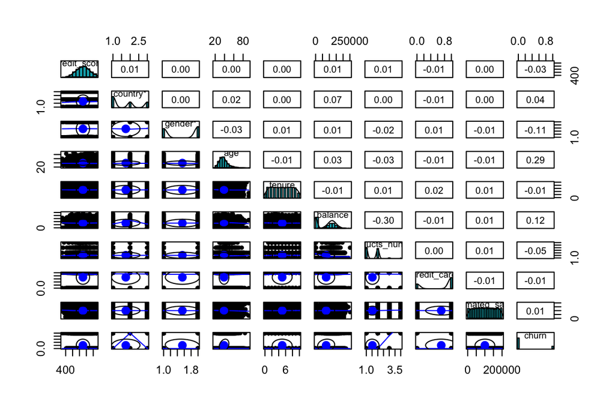

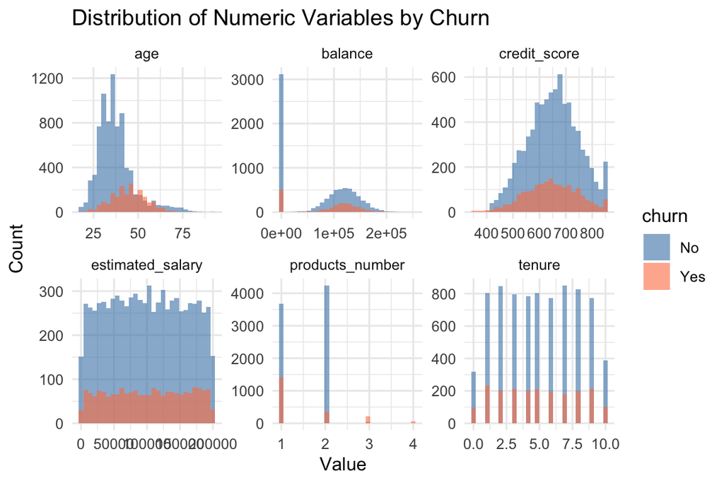

The churn-stratified histograms confirm that the churners are not simply a random subset of the population. Churners are over-represented among older customers, among customers with three or four products, and among customers with positive balances. These patterns reinforce the decision to discretize age and product count rather than enter them linearly.

# 5 Variable Transformation and Discretization

## 5.1 Standardized numerical variables

`age` is not standardized because it is discretized below.

## 5.2 Discretized variables

Three variables are discretized into categorical factors.

`age` becomes `age_band`, a five-level factor with categories `<=30`, `31-40`, `41-50`, `51-60`, and `60+`. The age distribution is strongly right-skewed, and the churn risk profile is non-monotonic, peaking in the 51–60 band rather than increasing steadily. A single linear term would average over this structure and understate the risk in the peak band.

`products_number` becomes `products_cat`, a four-level factor with levels 1, 2, 3, and 4. Churn risk is sharply non-monotonic in product count: the two-product group is the safest, while the three- and four-product groups are the riskiest. A linear term would fit a single slope through a U-shaped relationship and misspecify the model.

`balance` becomes `has_balance`, a binary flag distinguishing zero-balance customers from positive-balance customers. The continuous `balance` is retained alongside this flag, so the model can capture both the zero/non-zero distinction and the magnitude of the balance among those who hold one.

The remaining categorical and binary variables — `country`, `gender`, `credit_card`, and `active_member` — are used as factors without further transformation.

# 6 Standardizing Numerical Predictor Variables

Because the aim is a predictive model rather than an inferential one, the interpretation of individual coefficients is secondary to the model’s out-of-sample performance. Standardization of the four continuous predictors is therefore carried out inside the training pipeline, using training means and standard deviations, and the resulting statistics are stored so that the same transformation can be reapplied to the test set and, later, to new data at prediction time. This last point matters in practice: if the final model is deployed, the scoring function must reproduce every transformation applied here — the standardization, the age-band cut points, the product categories, and the zero-balance flag — before the coefficients can be used. A separate transformation function is the cleanest way to guarantee that.

# 7 Data Split - Training and Testing Data

The data are randomly split into a training set and a test set. Seventy percent of the records are assigned to training and thirty percent to testing. The training set is used for all model fitting, stepwise search, and cross-validation. The test set is held out entirely and is used only once, at the end of the analysis, to produce the performance figures reported to the client.

Because churn is imbalanced — roughly one in five customers leaves — the split is stratified on the response so that both partitions preserve the overall churn rate. Without stratification, a random split could produce a test set with a noticeably different churn rate and an unstable accuracy estimate.

```
FALSE Training rows: 7001
```

```
FALSE Testing rows:  2999
```

```
FALSE Churn rate — train: 0.2037 | test: 0.2037
```

The resulting partition contains roughly 7,000 training records and 3,000 test records, with the churn rate held approximately constant across the two sets.

# 8 Best Model Identification

All three models are fit on the training data using a logit link. For the cross-validation comparison below, a common cut-off of 0.5 is used to convert predicted probabilities into predicted classes. A 0.5 cut-off treats false positives and false negatives as equally costly, which is a reasonable default for a first comparison; in a deployed retention program the cut-off would be chosen with the relative costs of the two errors in mind.

```
FALSE Forward selection formula:
```

```
FALSE churn ~ products_cat + age_band + active_member + country + gender +
FALSE     has_balance + balance + credit_score
```

```
FALSE Backward selection formula:
```

```
FALSE churn ~ credit_score + country + gender + balance + active_member +
FALSE     products_cat + has_balance + age_band
```

Reduced (final) model — coefficient summary (training)

| Term | Estimate | Std.Error | z.value | p.value |
| --- | --- | --- | --- | --- |
| (Intercept) | -1.3077 | 0.1778 | -7.3534 | 0.0000 |
| credit_score | -0.0518 | 0.0361 | -1.4338 | 0.1516 |
| countryGermany | 1.0266 | 0.0923 | 11.1238 | 0.0000 |
| countrySpain | 0.0811 | 0.0929 | 0.8730 | 0.3827 |
| genderMale | -0.5272 | 0.0725 | -7.2744 | 0.0000 |
| balance | 0.1732 | 0.0891 | 1.9443 | 0.0519 |
| active_member | -1.0641 | 0.0763 | -13.9473 | 0.0000 |
| products_cat2 | -1.5581 | 0.0875 | -17.8089 | 0.0000 |
| products_cat3 | 2.6372 | 0.2248 | 11.7324 | 0.0000 |
| products_cat4 | 16.2285 | 198.1640 | 0.0819 | 0.9347 |
| has_balancePositive | -0.5825 | 0.1974 | -2.9513 | 0.0032 |
| age_band31-40 | 0.4989 | 0.1262 | 3.9522 | 0.0001 |
| age_band41-50 | 1.8207 | 0.1263 | 14.4191 | 0.0000 |
| age_band51-60 | 2.9256 | 0.1511 | 19.3555 | 0.0000 |
| age_band60+ | 1.7279 | 0.1869 | 9.2439 | 0.0000 |

## 8.1 Cross-Validation for Model Identification

The three candidate models are compared using five-fold stratified cross-validation on the training data. Five folds are chosen rather than ten because the churn rate is low enough that a small number of folds could leave individual validation folds with very few churn cases; five folds keep each validation fold large enough for a stable error estimate.

For each fold, each candidate model is refit on the remaining four folds and used to predict the held-out fold at the 0.5 cut-off. The prediction error — the proportion of held-out customers whose churn status is misclassified — is recorded, and the average across folds is reported. The model with the lowest average prediction error is preferred; when two models are essentially tied, the simpler model is chosen, following the principle of parsimony.

Average prediction errors of candidate models (5-fold CV, cut-off 0.5)

| Model | Avg_Prediction_Error |
| --- | --- |
| PE.1 (Full) | 0.1501 |
| PE.2 (Reduced) | 0.1498 |
| PE.3 (Null) | 0.2037 |

## 8.2 Final Model Reporting

Cross-validation identifies the best model, but the accuracy reported to the client must come from data that played no role in fitting or selection. The final reduced model is therefore applied to the withheld test set, and its accuracy and error rate are reported below.

Final model performance on withheld test data (cut-off 0.5)

| Metric | Value |
| --- | --- |
| Test-set accuracy | 0.8473 |
| Test-set prediction error | 0.1527 |

The final model classifies approximately 84.7 percent of held-out customers correctly at the 0.5 cut-off. Because the train/test split is random, re-running the analysis will produce slightly different figures; the reported number should be read as an estimate of out-of-sample accuracy rather than an exact constant.

# 9 ROC Analysis - Global Performance

Accuracy at a single cut-off gives an incomplete picture, particularly when the response is imbalanced. A model that predicts “no churn” for every customer would be roughly 80 percent accurate and yet completely useless, because it would never identify a customer at risk. The ROC curve addresses this by tracing the trade-off between the true positive rate (sensitivity) and the false positive rate (1 − specificity) across all possible cut-offs, and the area under that curve (AUC) summarizes the model’s ability to rank churners above non-churners. AUC is threshold-free and is the appropriate global measure of discrimination.

Because the ROC curve is used here for model selection, the curves are constructed on the training data, where each candidate model can be compared fairly. For each of the three candidate models, predicted probabilities are generated on the training set and passed to the `pROC` package, which computes the sensitivity and false positive rate at every cut-off and calculates the corresponding AUC.

Training-set AUC of candidate models

| Model | AUC |
| --- | --- |
| Full | 0.8478 |
| Reduced (final) | 0.8477 |
| Null | 0.5000 |

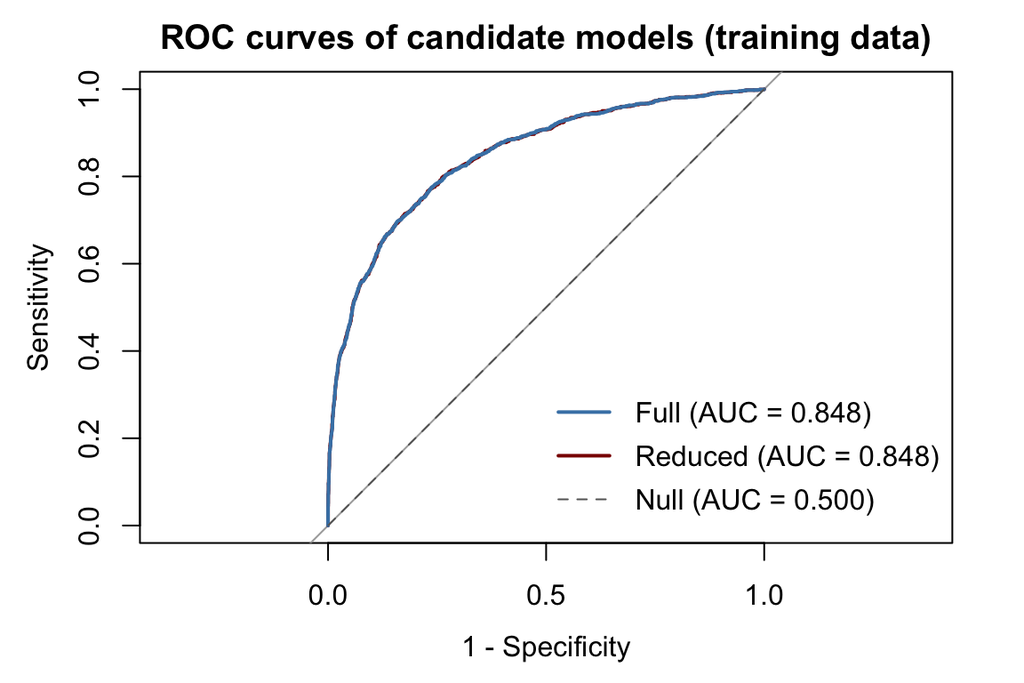

For completeness, the final model’s discrimination is also evaluated on the withheld test set, where the AUC provides an unbiased estimate of how the model would rank new customers.

Final model — test-set AUC with 95% DeLong CI

| Model | Test_AUC | CI_lower | CI_upper |
| --- | --- | --- | --- |
| Reduced (final) | 0.8307 | 0.8117 | 0.8497 |

Youden-optimal threshold on the test set

| threshold | sensitivity | specificity |
| --- | --- | --- |
| 0.1908673 | 0.7446809 | 0.7721943 |

The test-set AUC is close to the training-set AUC, which indicates that the model is not overfitting and that its discrimination generalizes to new customers. The Youden-optimal threshold — the cut-off that maximizes sensitivity plus specificity minus one — provides a natural default operating point when the two error types are weighted equally. In practice, a retention program would likely move the threshold toward higher sensitivity, since the cost of missing a genuine churner generally exceeds the cost of a retention offer sent to a customer who would have stayed.

# 10 Summary and Conclusion